# 2016 US Bike Share Activity Snapshot

- Introduction
- Posing Questions
- Data Collection and Wrangling
  - Condensing the Trip Data
- Exploratory Data Analysis
  - Statistics
  - Visualizations
- Conclusions

## Introduction

Over the past decade, bicycle-sharing systems have been growing in number and popularity in cities across the world. Bicycle-sharing systems allow users to rent bicycles for short trips, typically 30 minutes or less. Thanks to the rise in information technologies, it is easy for a user of the system to access a dock within the system to unlock or return bicycles. These technologies also provide a wealth of data that can be used to explore how these bike-sharing systems are used.

In this project, I am performing an exploratory analysis with Python as my programming language on data provided by [Motivate](https://www.motivateco.com/), a bike-share system provider for many major cities in the United States. I will be comparing the system usage between three large cities: New York City, Chicago, and Washington, DC. I will also see if there are any differences within each system for those users that are registered, regular users and those users that are short-term, casual users.

## Posing Questions

Write Python functions to answer these questions?

#### Basic Counts

**Question 1**: Which city has the highest number of trips?

**Question 2**: Which city has the highest proportion of trips made by subscribers?

**Question 3**: Which city has the highest proportion of trips made by short-term customers?

> **Note**: Bike-share systems are designed for riders to take short trips. Most of the time, users are allowed to take trips of 30 minutes or less with no additional charges, with overage charges made for trips of longer than that duration.

**Question 4**: What is the average trip length for each city?

**Question 5**: What proportion of rides made in each city are longer than 30 minutes?

**Question 6**: Dig deeper into the question of trip duration based on ridership. Within Chicago city, which type of user takes longer rides on average: Subscribers or Customers?

## Visualization Questions

**Question 7**: Create a histogram of the trip times for the Chicago city. Let us not separate the Subscribers and Customers for now: just collect all of the trip times and plot them without any limits.

**Question 8**: Use the parameters of the `.hist()` function to plot the distribution of trip times for the Subscribers Chicago City. Do the same thing for only the Customers. Add limits to the plots so that only trips of duration less than 75 minutes are plotted. As a bonus, set the plots up so that bars are in five-minute wide intervals.

**Question 9**: For each group, where is the peak of each distribution? How would you describe the shape of each distribution?

**Queston 10**: During the month of December, that is Holiday Season Subscriber's average trip length of each city?

**Question 11** : Draw New York City's Monthly Chart of average trip lengths? How would you conclude it?

## Data Collection and Wrangling

Now it's time to collect and explore our data. In this project, we will focus on the record of individual trips taken in 2016 from our selected cities: New York City, Chicago, and Washington, DC. Each of these cities has a page where we can freely download the trip data.:

- New York City (Citi Bike): [Link](https://www.citibikenyc.com/system-data)
- Chicago (Divvy): [Link](https://www.divvybikes.com/system-data)
- Washington, DC (Capital Bikeshare): [Link](https://www.capitalbikeshare.com/system-data)

If you visit these pages, you will notice that each city has a different way of delivering its data. Chicago updates with new data twice a year, Washington DC is quarterly, and New York City is monthly. **However, I did download the data and did the following.** The data has already been collected in the `/data/` folder of the project files. While the original data for 2016 is spread among multiple files for each city, the files in the `/data/` folder collect all of the trip data for the year into one file per city. Some data wrangling of inconsistencies in timestamp format within each city has already been performed. In addition, a random 2% sample of the original data is taken to make the exploration more manageable.

However, there is still a lot of data to investigate, so I started by looking at one entry from each of the cities we're going to analyze. Running the first code cell below loads some packages and functions that I will be using in the analysis. And, the second code cell to print out the first trip recorded from each of the cities (the second line of each data file), to understand the row headers and the values in them to go on further for performing data wrangling, sorting and filtering.

```python
## import all necessary packages and functions.
import csv # read and write csv files
from datetime import datetime # operations to parse dates
from pprint import pprint # use to print data structures like dictionaries in
                          # a nicer way than the base print function.

import math

# load library
import matplotlib.pyplot as plt #Visualization Lbrary
import numpy as np #
```

```python
def print_first_point(filename):
    """
    This function prints and returns the first data point (second row) from
    a csv file that includes a header row.
    """
    # print city name for reference
    city = filename.split('-')[0].split('/')[-1]
    print('\nCity: {}'.format(city))

    with open(filename, 'r') as f_in:
        ## Using the csv library to set up a DictReader object. ##
        ## Ref: https://docs.python.org/3/library/csv.html           ##
        trip_reader = csv.DictReader(f_in)

        ## Using a function on the DictReader object to read the     ##
        ## first trip from the data file and store it in a variable.     ##
        ## Ref: https://docs.python.org/3/library/csv.html#reader-objects ##
        first_trip = next(trip_reader)

        ## Using the pprint library to print the first trip. ##
        ## Ref: https://docs.python.org/3/library/pprint.html     ##
        pprint(first_trip)
    # output city name and first trip for later testing
    return (city, first_trip)

# list of files for each city
data_files = ['./data/NYC-CitiBike-2016.csv',
              './data/Chicago-Divvy-2016.csv',
              './data/Washington-CapitalBikeshare-2016.csv',]

# printing the first trip from each file, store in dictionary
example_trips = {}
for data_file in data_files:
    city, first_trip = print_first_point(data_file)
    example_trips[city] = first_trip
```

```
City: NYC
OrderedDict([('tripduration', '839'),
             ('starttime', '1/1/2016 00:09:55'),
             ('stoptime', '1/1/2016 00:23:54'),
             ('start station id', '532'),
             ('start station name', 'S 5 Pl & S 4 St'),
             ('start station latitude', '40.710451'),
             ('start station longitude', '-73.960876'),
             ('end station id', '401'),
             ('end station name', 'Allen St & Rivington St'),
             ('end station latitude', '40.72019576'),
             ('end station longitude', '-73.98997825'),
             ('bikeid', '17109'),
             ('usertype', 'Customer'),
             ('birth year', ''),
             ('gender', '0')])

City: Chicago
OrderedDict([('trip_id', '9080545'),
             ('starttime', '3/31/2016 23:30'),
             ('stoptime', '3/31/2016 23:46'),
             ('bikeid', '2295'),
             ('tripduration', '926'),
             ('from_station_id', '156'),
             ('from_station_name', 'Clark St & Wellington Ave'),
             ('to_station_id', '166'),
             ('to_station_name', 'Ashland Ave & Wrightwood Ave'),
             ('usertype', 'Subscriber'),
             ('gender', 'Male'),
             ('birthyear', '1990')])

City: Washington
OrderedDict([('Duration (ms)', '427387'),
             ('Start date', '3/31/2016 22:57'),
             ('End date', '3/31/2016 23:04'),
             ('Start station number', '31602'),
             ('Start station', 'Park Rd & Holmead Pl NW'),
             ('End station number', '31207'),
             ('End station', 'Georgia Ave and Fairmont St NW'),
             ('Bike number', 'W20842'),
             ('Member Type', 'Registered')])
```

If our functions are correctly coded then it should printout each city name (which has been parsed from the data file name) that the first trip has been parsed in the form of a dictionary. When we set up a `DictReader` object, the first row of the data file is normally interpreted as column names. Every other row in the data file will use those column names as keys, as a dictionary is generated for each row.

This will be useful for us in answering the posing questions since we can refer to quantities by an easily-understandable label instead of just a numeric index. For example, if we have a trip stored in the variable `row`, then we would rather get the trip duration from `row['duration']` instead of `row[0]`.

### Condensing the Trip Data

We can also observe from the above printout that each city provides different information. Even where the information is the same, the column names and formats are sometimes different. To make things as simple as possible when we get to the actual exploration, we should trim and clean the data. Cleaning the data makes sure that the data formats across the cities are consistent, while trimming focuses only on the parts of the data we are most interested in to make the exploration easier to work with.

According to the posing questions to be answered, we will generate new data files with five values of interest for each trip: trip duration, starting month, starting hour, day of the week, and user type. Each of these may require additional wrangling depending on the city:

- **Duration**: This has been given to us in seconds (New York, Chicago) or milliseconds (Washington). A more natural unit of analysis will be if all the trip durations are given in terms of minutes.
- **Month**, **Hour**, **Day of Week**: Ridership volume is likely to change based on the season, time of day, and whether it is a weekday or weekend. Use the start time of the trip to obtain these values. The New York City data includes the seconds in their timestamps, while Washington and Chicago do not. The [`datetime`](https://docs.python.org/3/library/datetime.html) package will be very useful here to make the needed conversions.
- **User Type**: It is possible that users who are subscribed to a bike-share system will have different patterns of use compared to users who only have temporary passes. Washington divides its users into two types: 'Registered' for users with annual, monthly, and other longer-term subscriptions, and 'Casual', for users with 24-hour, 3-day, and other short-term passes. The New York and Chicago data uses 'Subscriber' and 'Customer' for these groups, respectively. For consistency, we will convert the Washington labels to match the other two.

## Helper Functions

We would create three helper functions to clean the data as per the specifications described above so that for each city, we have duration in minutes, Month in number, Hour in 24 hr system, and the user type as either Subscriber or a Customer.

To do this, the following functions are defined:

1. duration_in_mins(dtum,city)
2. time_of_trip(datum,city)
3. type_of_user(datum,city)

To get into the details of how these functions work, please go through them, we have also defined test cases referencing the first row in each city with the respective data set.

```python
def duration_in_mins(datum, city):
    """
    Takes as input a dictionary containing info about a single trip (datum) and
    its origin city (city) and returns the trip duration in units of minutes.

    Since Washington is in terms of milliseconds while Chicago and NYC
    are in terms of seconds.

    We also know that the csv module reads in all of the data as strings, including numeric
    values. We will need a function to convert the strings into an appropriate
    numeric type when making transformations.
    Ref: https://docs.python.org/3/library/functions.html
    """
    #Reference for initialising constant:
    #https://stackoverflow.com/questions/24133929/how-do-you-declare-a-global-constant-in-python
    #Constant for converting secs to mins
    SECS_TO_MINS = 60
    #Constant for converting milli seconds to seconds
    MS_TO_SECS = 1000

    #Checks for the Washington city to return the duration
    if (city == 'Washington'):
        #Converts the trip duration value into float
        triptime = float(datum['Duration (ms)'])
        duration = triptime/(MS_TO_SECS * SECS_TO_MINS) #Converts from milliseconds to minutes
    else:
        triptime = float(datum['tripduration']) #Converts trip duration into float
        duration = triptime/(SECS_TO_MINS) #Converts from seconds to minutes

    #Returns the duration in minutes
    return duration


# Some tests to check that our code works. There should be no output if all of
# the assertions pass. The `example_trips` dictionary was obtained from when
# we printed the first trip from each of the original data files.
tests = {'NYC': 13.9833,
         'Chicago': 15.4333,
         'Washington': 7.1231}

for city in tests:
    assert abs(duration_in_mins(example_trips[city], city) - tests[city]) < .001
```

```python
def date_format(dt_format):
    """
    Takes in a date time object and returns the month, hour and day of the week as a tuple
    """

    #Constant - Days of the week list
    DAYS_OF_WEEK = ['Monday','Tuesday', 'Wednesday', 'Thursday', 'Friday', 'Saturday','Sunday']

    #Stores the month as an int in month
    month = dt_format.month

    #Stores the hour as an int format
    hour = dt_format.hour

    #Stores the day of the week as string format
    day_of_week = DAYS_OF_WEEK[dt_format.isoweekday() - 1]

    return month,hour,day_of_week
```

```python
def time_of_trip(datum, city):
    """
    Takes as input a dictionary containing info about a single trip (datum) and
    its origin city (city) and returns the month, hour, and day of the week in
    which the trip was made.

    Considering that NYC includes seconds, while Washington and Chicago do not.

    We should use the datetime module to parse the original date
    strings into a format that is useful for extracting the desired information.
    Ref: https://docs.python.org/3/library/datetime.html#strftime-and-strptime-behavior
    """

    #Date time Formats list and probable date_keys list in the files
    timestamp_format = ['%m/%d/%Y %H:%M', '%m/%d/%Y %H:%M:%S']
    date_key = ['Start date', 'starttime']

    #Step1 : convert str to to datetime format
        #Sub Steps: I need to know the variable first where I can access the date
        #I need to know how to convert an str format to a datetime format
    #Step2: Find the month
    #Step3: Find the hour
    #Step4: Find the day of the week


    if (city == 'Washington'):
        dt = datetime.strptime(datum[date_key[0]], timestamp_format[0])
        return date_format(dt)
        #month = dt.month
        #hour = dt.hour
        #day_of_week = days_of_week[dt.isoweekday() - 1]
    elif(city == 'NYC'):
        dt = datetime.strptime(datum[date_key[1]], timestamp_format[1])
        return date_format(dt)
        #month = dt.month
        #hour = dt.hour
        #day_of_week = days_of_week[dt.isoweekday() - 1]
    elif(city == 'Chicago'):
        dt = datetime.strptime(datum[date_key[1]], timestamp_format[0])
        return date_format(dt)


# Some tests to check that our code works. There should be no output if all of
# the assertions pass. The `example_trips` dictionary was obtained from when
# we printed the first trip from each of the original data files.
tests = {'NYC': (1, 0, 'Friday'),
         'Chicago': (3, 23, 'Thursday'),
         'Washington': (3, 22, 'Thursday')}

for city in tests:
    assert time_of_trip(example_trips[city], city) == tests[city]
```

```python
def type_of_user(datum, city):
    """
    Takes as input a dictionary containing info about a single trip (datum) and
    its origin city (city) and returns the type of system user that made the
    trip.

    Remember that Washington has different category names compared to Chicago
    and NYC.
    """

    user_types = ['Member Type', 'usertype']

    #Removing the discrepancy of the user_types between each cities
    if (city == 'Washington'):
        user_type = datum[user_types[0]]
        if(user_type == 'Registered'):
            user_type = 'Subscriber'
        else:
            user_type = 'Customer'
    else:
        user_type = datum[user_types[1]]

    return user_type


# Some tests to check that our code works. There should be no output if all of
# the assertions pass. The `example_trips` dictionary was obtained from when
# we printed the first trip from each of the original data files.
tests = {'NYC': 'Customer',
         'Chicago': 'Subscriber',
         'Washington': 'Subscriber'}

for city in tests:
    assert type_of_user(example_trips[city], city) == tests[city]
```

The above helper functions help us cleaning the data supplied by each reach record. The next step would be to recreate the data file with a cleaned data

So, we write the following function to do just that. The condense_data(in_file,out_file,city) function does write a file and reads a file as well for each city.

```python
def condense_data(in_file, out_file, city):
    """
    This function takes full data from the specified input file
    and writes the condensed data to a specified output file. The city
    argument determines how the input file will be parsed.

    """
    #Writes the out_file and reads the in_file
    with open(out_file, 'w') as f_out, open(in_file, 'r') as f_in:
        # set up csv DictWriter object - writer requires column names for the
        # first row as the "fieldnames" argument
        out_colnames = ['duration', 'month', 'hour', 'day_of_week', 'user_type']
        trip_writer = csv.DictWriter(f_out, fieldnames = out_colnames)
        trip_writer.writeheader()

        ## Set up csv DictReader object ##
        trip_reader = csv.DictReader(f_in)

        # Collect data from and process each row
        for row in trip_reader:
            # Setting up a dictionary to hold the values for the cleaned and trimmed
            # Data point
            new_point = {}

            ## Using the helper functions, get the cleaned data from  ##
            ## the original data dictionaries.                              ##
            ## Note that the keys for the new_point dictionary should match ##
            ## the column names set in the DictWriter object above.         ##
            new_point['duration'] = duration_in_mins(row, city)
            new_point['month'], new_point['hour'], new_point['day_of_week'] = time_of_trip(row, city)
            new_point['user_type'] = type_of_user(row, city)

            ## Write the processed information to the output file.     ##
            ## Ref: https://docs.python.org/3/library/csv.html#writer-objects ##
            trip_writer.writerow(new_point)
```

```python
# Running the cell assures our work
city_info = {'Washington': {'in_file': './data/Washington-CapitalBikeshare-2016.csv',
                            'out_file': './data/Washington-2016-Summary.csv'},
             'Chicago': {'in_file': './data/Chicago-Divvy-2016.csv',
                         'out_file': './data/Chicago-2016-Summary.csv'},
             'NYC': {'in_file': './data/NYC-CitiBike-2016.csv',
                     'out_file': './data/NYC-2016-Summary.csv'}}

for city, filenames in city_info.items():
    condense_data(filenames['in_file'], filenames['out_file'], city)
    print_first_point(filenames['out_file'])
```

```
City: Washington
OrderedDict([('duration', '7.123116666666666'),
             ('month', '3'),
             ('hour', '22'),
             ('day_of_week', 'Thursday'),
             ('user_type', 'Subscriber')])

City: Chicago
OrderedDict([('duration', '15.433333333333334'),
             ('month', '3'),
             ('hour', '23'),
             ('day_of_week', 'Thursday'),
             ('user_type', 'Subscriber')])

City: NYC
OrderedDict([('duration', '13.983333333333333'),
             ('month', '1'),
             ('hour', '0'),
             ('day_of_week', 'Friday'),
             ('user_type', 'Customer')])
```

## Exploratory Data Analysis

Now that we have the data collected and wrangled, we're ready to start exploring the data. In this section we will write some code to compute descriptive statistics from the data. We will also introduce to the `matplotlib` library to create some basic histograms of the data.

### Statistics

Creating some helper functions to answer the Posing Questions.

```python
def check_for_datatype(var1,condition):
    """
    Converts the var1 into the same datatype as the datatype of condition
    var1: A variable whose data type must be altered to match with the data type of condition
    condition: A variable whose data type must be assigned to var1
    """
    #Checks for inequality in two data types
    if(type(var1) != type(condition)):
        #Stores the data type of condition
        d_type = type(condition)
        #Returns var with the same data type as that of condition
        return d_type(var1)
    else:
        return var1
```

```python
def check_condition(first,operator,second):
    """
    Compares the first operand with the second operand given the operator
    first: First Operand
    operator: Comparison Operator
    second: Second Operand
    """
    #Reference: Udacity's Intro to Java Course had these statements to check true or false with operators
    if(operator == '='):
        return (first == second)
    elif(operator == '>'):
        return (first > second)
    elif(operator == '>='):
        return (first >= second)
    elif(operator == '<'):
        return (first < second)
    elif(operator == '<='):
        return (first <= second)
    elif(operator == '!='):
        return (first != second)
```

```python
def count_no(datum, col_names, operators, conditions):
    """
    Returns True if all conditions are met
    datum: row of each record in a file
    col_name: List of the names of columns to compare
    conditions: A list of conditions to be checked for
    operators: A list of operators used for comparison between rows of col names and the conditions given
    """


    #For future iterative programming
    length = max(len(col_names),len(conditions),len(operators))

    #Iterations for the maximum of length
    index = 0

    #Expression stores a list of Bool values either True or False
    expression = []

    for index in range(length):
        first_operand = datum[col_names[index]]
        op = operators[index]
        second_operand = conditions[index]

        first_operand = check_for_datatype(first_operand,second_operand)
        expression.append(check_condition(first_operand,op, second_operand))

    #Stores the list of Expression as a set
    expr = set(expression)

    #Checks the bool value of the expression
    var = (len(expr) == 1 and (True in expr))
    #if the var is true count is incremented and returns 1 else it returns 0
    if var:
        return True
    else:
        return False
```

```python
def open_file(filename, col_names, conditions, op, count_len):
    """
    Depending on instruction this function either counts or adds the trip length
    filename: filename to be read as a csv file
    col_names: col_names to be compared with the condition and the op
    conditions: conditions with respect to the col names
    op: Operators required to compare the conditions and col names
    count_len: string which either contains count or trip_len to identify and return the respectie calculation
    """


    #Opens the file filename as a read only file
    with open(filename, 'r') as f_in:
        # set up csv reader object
        #Reads the rows of the file
        reader = csv.DictReader(f_in)

        # initialize count variables ,'duration', 30.0, ,'>'
        coun_len = 0.0
        #Stroes the value of length of the trips

        index = 0
        # Iterates through every row in the reader
        for row in reader:
            #Increments the count
            if(count_len == 'count'):
                proceed = count_no(row,col_names,op,conditions)
                if (proceed):
                    coun_len += 1
            #Increments the trip_duration
            elif(count_len == 'trip_len'):
                proceed = count_no(row,col_names,op,conditions)
                if (proceed):
                    coun_len += float(row['duration'])
    #trip_len = math.ceil(trip_len*100)/100

    return coun_len
```

```python
def proportion(mem_dic, tot_dic):
    """
    Calculates the proportion or we can division of two dictionary values to return a dictionary value pair

    mem_dic: A filtered dictionary of key value pair
    tot_dic: The sum total dictionary of key value pairs
    @returns a dictionary object with key-value
    """

    proportion_var = {}

    for keys in tot_dic:
        proportion_var[keys] = mem_dic[keys]/tot_dic[keys]

    return proportion_var
```

```python
#Declaring empty dictionaries which would contain city - count pair of user_types
#City - Subscriber records
sub_count = {}
#City - Customer records
cust_count = {}

#Declaring empty dictionaries which would contain city - trip length pair of user_types
#City - Subscriber trip length duration
sub_trip_len = {}
#City - Customer trip length duration
cust_trip_len = {}


#Declaring empty dictionaries which would contain city - count pair of all the records
tot_count = {}

#Declaring empty dictionaries which would contain city - trip length pair of all the records
tot_trip_len = {}
```

```python
#Iterates over all element in city_info
for city, filenames in city_info.items():
    #Stores the subscriber count wrt city
    sub_count[city] = int(open_file(filenames['out_file'], ['user_type'],['Subscriber'], ['='],'count'))
    #Stores the Subscriber trip length wrt city
    sub_trip_len[city] = open_file(filenames['out_file'], ['user_type'],['Subscriber'], ['='], 'trip_len')

    #Stores the customer count wrt city in int format
    cust_count[city]  = int(open_file(filenames['out_file'],['user_type'],['Customer'], ['='],'count'))
    #Stores the customer trip length wrt city
    cust_trip_len[city] = open_file(filenames['out_file'],['user_type'],['Customer'], ['='], 'trip_len')

    #Calculates the total recors and total trip length
    tot_count[city] = sub_count[city] + cust_count[city]
    tot_trip_len[city] = sub_trip_len[city] + cust_trip_len[city]
```

```python
#Question 1

#Maxmum number of trips in the city
max_trip_city = max(tot_count, key = tot_count.get)
#In Resources
#This answers how many trips the max_trip city have had
max_trip_count = max(tot_count.values())
```

```python
#Answer to Question 1 printed in readable format

statement = "{} city leads the highest number of trips with {} trips"
print("Answer to Question 1: Which city has the highest number of trips?")
print(statement.format(max_trip_city,max_trip_count))
```

```
Answer to Question 1: Which city has the highest number of trips?
NYC city leads the highest number of trips with 276081 trips
```

```python
#Question 2 and 3

#Saves the percentage of subscribers wrt city
percent_of_sub = proportion(sub_count,tot_count)
#Stores the percentage of customers with respect to the city
percent_of_cust = proportion(cust_count,tot_count)

#Finds the city with maximum percentage of subscribers
max_per_city_of_sub = max(percent_of_sub, key = percent_of_sub.get)
#The percentage value of subscribers in the city with highest proportion of subscribers
max_per_count_sub = math.ceil(max(percent_of_sub.values()) * 1000)/10

#Finds the city with maximum percentage of customers
max_per_city_of_cust = max(percent_of_cust, key = percent_of_cust.get)
#The percentage value of subscribers in the city with highest proportion of subscribers
max_per_count_cust = math.ceil(max(percent_of_cust.values()) * 1000)/10
```

```python
statement1 = "{} city has the highest proportion of {} with {}%"

#Answer 2
print("Answer to Question 2: Which city has the highest proportion of trips made by subscribers?")
print(statement1.format(max_per_city_of_sub, 'Subscribers', max_per_count_sub))

print("\n")
#Answer 3
print("Answer to Question 3: Which city has the highest proportion of trips made by short-term customers?")
print(statement1.format(max_per_city_of_cust, 'Customers', max_per_count_cust))
```

```
Answer to Question 2: Which city has the highest proportion of trips made by subscribers?
NYC city has the highest proportion of Subscribers with 89.1%


Answer to Question 3: Which city has the highest proportion of trips made by short-term customers?
Chicago city has the highest proportion of Customers with 23.8%
```

```python
#Answer 4
print("Answers to Question 4: What is the average trip length for each city? ")
print("")
statement4b = "{} city has the average trip length - {} mintues"
avg_trip_len = proportion(tot_trip_len, tot_count)

for city in avg_trip_len:
    print(statement4b.format(city,int(avg_trip_len[city])))
```

```
Answers to Question 4: What is the average trip length for each city?

Washington city has the average trip length - 18 mintues
Chicago city has the average trip length - 16 mintues
NYC city has the average trip length - 15 mintues
```

```python
#Dictionary saving the overage trips wrt city and user type
#Subscriber Overage trips wrt city
sub_over_trips = {}
#Customer overage trips wrt city
cust_over_trips = {}

#Total Overage trips wrt city
tot_over_trips = {}
```

```python
filter_col_names = ['user_type','duration']
condition1 = ['Subscriber', 30.0]
condition2 = ['Customer', 30.0]
operator = ['=','>']
```

```python
for city, filenames in city_info.items():
    #Stores the no of overage trips of customers and subscribers
    sub_over_trips[city] = int(open_file(filenames['out_file'], filter_col_names,condition1, operator,'count'))
    cust_over_trips[city] = int(open_file(filenames['out_file'], filter_col_names,condition2, operator,'count'))

    #Add the overage trips
    tot_over_trips[city] = sub_over_trips[city] + cust_over_trips[city]
```

```python
#Calls the proportion function and saves the proportion of trips in the variable as a city - overage trip count pair
per_of_over_trips = proportion(tot_over_trips, tot_count)
```

```python
#Answer Question 5
print("Answer to Question 5: What proportion of rides made in each city are longer than 30 minutes?")
print("")

for city in per_of_over_trips:
    #Stores the overage trips into percentage
    trips = math.ceil(per_of_over_trips[city]*1000)/10
    #Prints the overage trips wrt each city
    print("{}% of rides made in {} city are longer than 30 minutes.".format(trips,city))
```

```
Answer to Question 5: What proportion of rides made in each city are longer than 30 minutes?

10.9% of rides made in Washington city are longer than 30 minutes.
8.4% of rides made in Chicago city are longer than 30 minutes.
7.3% of rides made in NYC city are longer than 30 minutes.
```

**Question 4c**: Dig deeper into the question of trip duration based on ridership. Choose one city. Within that city, which type of user takes longer rides on average: Subscribers or Customers?

**Answer**:

1. **Chicago** city has the average Subscriber trip duration to be **12 minutes** and the average Customer trip duration to be **30 minutes**.

```python
avg_sub_trip_len = {}
avg_cust_trip_len = {}

avg_sub_trip_len = proportion(sub_trip_len, sub_count)
avg_cust_trip_len = proportion(cust_trip_len, cust_count)
```

```python
#Answer 6

out = "{} city has the average Subscriber trip duration to be {} minutes and the average Customer trip duration to \nbe {} minutes."


sub_trip = int(avg_sub_trip_len['Chicago'])
cust_trip = int(avg_cust_trip_len['Chicago'])

print("Answer to Question 6: Dig deeper into the question of trip duration based on ridership. Within Chicago city, which \ntype of user takes longer rides on average: Subscribers or Customers? \n")
print(out.format('Chicago', sub_trip,cust_trip))
```

```
Answer to Question 6: Dig deeper into the question of trip duration based on ridership. Within Chicago city, which
type of user takes longer rides on average: Subscribers or Customers?

Chicago city has the average Subscriber trip duration to be 12 minutes and the average Customer trip duration to
be 30 minutes.
```

### Visualizations

The last set of values that you computed should have pulled up an interesting result. While the mean trip time for Subscribers is well under 30 minutes, the mean trip time for Customers is actually equal to 30 minutes! It will be interesting for us to look at how the trip times are distributed. In order to do this, we will be using new library `matplotlib` which was imported to the code.

```python
# the  following is a 'magic word' that allows for plots to be displayed
# inline with the notebook. Ref: http://ipython.readthedocs.io/en/stable/interactive/magics.html

%matplotlib inline
```

We will be using matplotlib's pyplot package to create a histogram of the trip times for the Chicago city. Let us not separate the Subscribers and Customers for now: we would just collect all of the trip times and plot them.

```python
## Use this and additional cells to collect all of the trip times as a list ##
## and then use pyplot functions to generate a histogram of trip times.     ##

def fetch_col_data(filename, fetchcolname = 'duration', filter_col_names = [], operators = [], conditions = []):
    """
    Fetches the data from the column 'duration' or any column stated
    filename: Name of the file whose data needs to be fetched

    The fetched column data is required by filtering the values under filter col_name
    with conditions satisfied with the respective operators.
    """

    with open(filename, 'r') as f_in:
        # set up csv reader object
        reader = csv.DictReader(f_in)
        #Sets the duration as empty list
        duration = []

        #Iterates over all the rows in the file
        for row in reader:
            #If there is a value given to filter it will run the below if block
            if filter_col_names:
                #Returns true or false by running the count function
                function_name =  count_no(row, filter_col_names,operators,conditions)
                if(function_name):
                    duration.append(row['duration'])
            else:
                duration.append(row['duration'])

        return duration
```

```python
file = city_info['Chicago']['out_file']
```

```python
#lst of all trip durations in string format
lst = fetch_col_data(file)
#Stores the list as a float format with two decimals
final_data = []

for item in lst:
    #Converts each string to float with 2 decimal places
    item = math.ceil(float(item)*100)/100
    final_data.append(item)
```

```
Answer to Question 7: Create a histogram of the trip times for the Chicago city. Let us not separate the Subscribers and Customers for now: just collect all of the trip times and plot them without any limits.
```

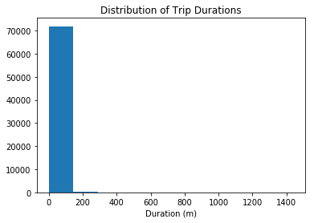

```python
#Answer 7

print("Answer to Question 7: Create a histogram of the trip times for the Chicago city. Let us not separate the Subscribers and Customers for now: just collect all of the trip times and plot them without any limits.")

plt.hist(final_data)
plt.title('Distribution of Trip Durations')
plt.xlabel('Duration (m)')
plt.show()
```

Since we did not use the limits in the above histogram we're looking at a plot that's completely unexpected. The plot consists of one extremely tall bar on the left, maybe a very short second bar, and a whole lot of empty space in the center and right. Taking a look at the duration values on the x-axis. This suggests that there are some highly infrequent outliers in the data. Instead of reprocessing the data, we will use additional parameters with the `.hist()` function to limit the range of data that is plotted. Refetence Documentation for the function can be found [[here]](https://matplotlib.org/devdocs/api/_as_gen/matplotlib.pyplot.hist.html#matplotlib.pyplot.hist).

```python
#File name to be used
file = city_info['Chicago']['out_file']
#Filtering Column
filtercolname = ['user_type']
#Operator to pass as an function argument
operator = ['=']
#First Condition
condition1 = ['Subscriber']
#Second Condition
condition2 = ['Customer']
```

```python
#Stores the data of subscribers as string
data_sub = fetch_col_data(file,'duration', filtercolname, operator, condition1)
#Stores the trip duration of customer as string
data_cust = fetch_col_data(file,'duration', filtercolname, operator, condition2)
```

```python
#Cleaning the data to use it as an float with 2 decimals
clean_data_sub = []
#Iterating over the data of subscribers
for item in data_sub:
    #Conveting the data to float
    item = math.ceil(float(item)*100)/100
    clean_data_sub.append(item)
```

```python
#Cleaning the data of customers
#Iterating over the data of customers
clean_data_cust = []
for item in data_cust:
    item = math.ceil(float(item)*100)/100
    clean_data_cust.append(item)
```

[output not shown]

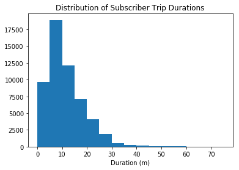

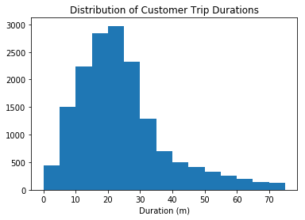

```python
#Answer 7

print("Answer to Question 7: Use the parameters of the `.hist()` function to plot the distribution of trip times for the Subscribers Chicago City. Do the same thing for only the Customers. Add limits to the plots so that only trips of duration less than 75 minutes are plotted. As a bonus, set the plots up so that bars are in five-minute wide intervals. ")

#Subscriber Trip Duration
#Parameters for drawing histogram, with the data set and restricting the graph to only show trips of duration less
#than 75 minutes
plt.hist(clean_data_sub, [0,5,10,15,20,25,30,35,40,45,50,55,60,65,70,75])
#Title of the histogram
plt.title('Distribution of Subscriber Trip Durations')
#x axis label
plt.xlabel('Duration (m)')
#Draws the histogram
plt.show()


#Customer trip Duration


#Parameters for drawing histogram, with the data set and restricting the graph to only show trips of duration less
#than 75 minutes
plt.hist(clean_data_cust, [0,5,10,15,20,25,30,35,40,45,50,55,60,65,70,75])
#Title of the histogram
plt.title('Distribution of Customer Trip Durations')
#x axis label
plt.xlabel('Duration (m)')
#Draws the histogram
plt.show()
```

**Question 9**: For each group, where is the peak of each distribution? How would you describe the shape of each distribution?

Peak of the distribution

1. For subscribers the highest point is at 5 minutes
2. For customers the peak point is at 20 minutes

```python
## Use this and additional cells to continue to explore the dataset. ##
## Once you have performed your exploration, document your findings  ##
## in the Markdown cell above.                                       ##
#Empty cities list
cities = []
#Avg Trip Length in the month of december : City - Trip Length Pair
avg_sub_tl_m12_lst = []
#The columns to be filtered
filter_col_name = ['user_type','month']
#Operators to check between column name record and the condition given
operator = ['=','=']
#Condition to be checked for
condition = ['Subscriber', 12]
#Subscriber Trip count in the month of December wrt city
sub_tc_m12 = {}
#Subscriber trip length in the month of december wrt city
sub_tl_m12 = {}
#Average subcriber trip length in the month of December wrt city
avg_sub_tl_m12 = {}

for city,filenames in city_info.items():
    #Appends the city as a list to display on x axis
    cities.append(city)
    #Subscriber trip count in the december month
    sub_tc_m12[city] = int(open_file(filenames['out_file'], filter_col_name,condition,operator,'count'))
    #Subscriber trip length in the month of december
    sub_tl_m12[city] = math.ceil(float(open_file(filenames['out_file'], filter_col_name,condition,operator,'trip_len'))*100)/100
    #Average Subscriber trip length wrt city
    avg_sub_tl_m12[city] = int(sub_tl_m12[city]/sub_tc_m12[city])
    #Average subscriber trip length saved as a list for a bar graph
    avg_sub_tl_m12_lst.append(avg_sub_tl_m12[city])
```

```
Answer to Question 10: During the month of December, that is Holiday Season Subscriber's average trip length of each city?
```

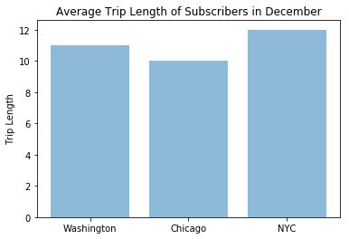

```python
#Answer Question 10

#Reference: https://pythonspot.com/matplotlib-bar-chart/
print("Answer to Question 10: During the month of December, that is Holiday Season Subscriber's average trip length of each city?")
#Saves and arranges the columns in a bar
y_pos = np.arange(len(cities))
#Plots the bar with the length, data, alignment and a little lighter color
plt.bar(y_pos, avg_sub_tl_m12_lst, align='center', alpha=0.5)
#X axis data and labels
plt.xticks(y_pos, cities)
#Y axis labels
plt.ylabel('Trip Length')
#Title of the bar graph
plt.title('Average Trip Length of Subscribers in December')
#Shows the bar graph
plt.show()
```

```python
import calendar
```

```python
#Answer to Question 11

#Stores the month number
index = 1

filter_col_name = ['month']
operator = ['=']

month_name = []
#List for gathering data on average trip length of each month
avg_tl_NYC_month = []

while (index <= 12):
    #Appends the month name to the list
    month_name.append(calendar.month_abbr[index])
    #Stores the condition as month number
    condition = [index]
    #Trip Count in the month as an int
    tc_m_NYC = int(open_file(city_info['NYC']['out_file'], filter_col_name,condition,operator,'count'))
    #Trip Length in the month as an int
    tl_m_NYC = int(open_file(city_info['NYC']['out_file'], filter_col_name,condition,operator,'trip_len'))
    #Average trip length
    avg_tl_NYC_month.append(tl_m_NYC/tc_m_NYC)
    #Increments the month number
    index+=1
```

```python
print("Answer to Question 11: New York City's Monthly Chart of average trip lengths.")

y_pos = np.arange(len(month_name))

plt.bar(y_pos, avg_tl_NYC_month, align='center', alpha=0.2)
plt.xticks(y_pos, month_name)
#Y axis label of the graph
plt.ylabel('Trip Length (minutes)')
#Title of the bar graph
plt.title('Average Trip Lengths (monthly) in NYC')
#DRAWS THE BAR GRAPH
plt.show()
```

[output not shown]

## Conclusions

This is only a sampling of the data analysis process: from generating questions, wrangling the data, and to exploring the data. Normally, at this point in the data analysis process, we might want to draw conclusions about the data by performing a statistical test or fitting the data to a model for making predictions.

```python
from subprocess import call
call(['python', '-m', 'nbconvert', 'Bike_Share_Analysis.ipynb'])
```